# HW6_syQiu

Author

Shuyi Qiu

# Set-up

```r
library(tidyverse)
library(infer)
library(janitor) ## for convenient "table" functions
library(gssr)    ## for access to GSS data
library(ggplot2)
library(reshape)
set.seed(321)
## You can choose another ggplot2 theme, obviously.
## Windows users might not have this font available!
theme_set(theme_light(base_family = "Optima"))
```

# 6.1 The Truth is Known

## 6.1.2 Choose Sample Size

### Method 1. Simulations

From the example with a poll size of 1000, we know that the standard error is approximately 0.01578. Therefore to choose sample size to make the standard error less than 0.05, we can construct a grid of 1000 by the step of 1, and compute the standard error for each sample size.

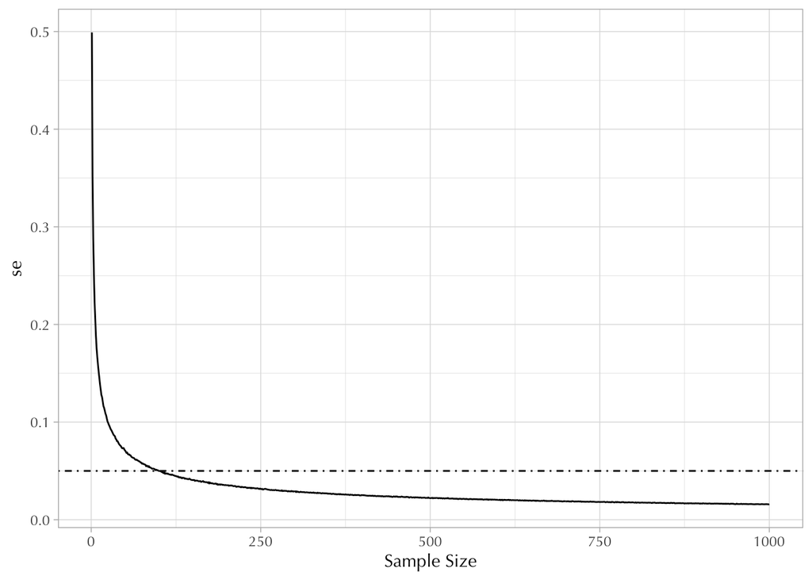

```r
# Define the function
sample_se <- function(sample_size){
  S <- 1e4 # Number of simulated draws
  poll_size <- sample_size # Sample size
  draws <- rbinom(S, size = poll_size, prob = 0.53)
  proportions <- draws / poll_size
  se <- sd(proportions)
  return(se)
}

# Construct the simulations grid for different sample size
sim_grid <- data.frame(sample_size = c(1:1000)) |>
  rowwise() |>
  mutate(se = sample_se(sample_size))

# Plot se v.s. sample size
ggplot(sim_grid, aes(x = sample_size, y = se)) +
  geom_line() +
  geom_hline(yintercept = 0.05, linetype = "dotdash") +
  xlab("Sample Size") +
  ylab("se")
```

```r
# The minimum sample size to have se <= 0.05
min(sim_grid |> filter(se <= 0.05) |> select(sample_size))
```

```
[1] 101
```

We can see from the line plot that standard error gets lower when sample size increases. The dashed horizontal line marks a standard error of 0.05. The intersection point is located at a sample size of 101.

### Method 2. Math

We can use mathematical way to verify the simulation results.

$$se_p=\sqrt{\frac{p(1-p)}{n}}=\sqrt{\frac{0.53*0.47}{n}}\leq0.05$$

$$n\geq\frac{0.53*0.47}{0.0025}$$

$$n \ge 99.64$$

Therefore the minimum n is 100, which is close to the result from simulation.

## 6.1.5 Hypothesis Testing

```r
set.seed(321)
# Establish the sample
one_dataset <- rbinom(1000, size = 1, prob = 0.53)
glimpse(one_dataset)
```

```
 int [1:1000] 0 0 1 1 1 1 1 1 1 0 ...
```

```r
# Estimated proportion
prop_hat <- mean(one_dataset)
prop_hat
```

```
[1] 0.513
```

```r
# Bootstrap
boot_stats <- replicate(1e4, {
  resample <- sample(one_dataset, replace = TRUE)
  mean(resample)
})
# Confidence interval, constructed from the the data we get to observe
ci95 <- quantile(boot_stats, c(0.025, 0.975))
ci95
```

```
 2.5% 97.5%
0.482 0.544
```

```r
# Math way
se_hat <- sqrt(prop_hat * (1 - prop_hat)/1000)
se_hat
```

```
[1] 0.01580604
```

```r
qnorm(c(0.025, 0.975), mean = prop_hat, sd = se_hat)
```

```
[1] 0.4820207 0.5439793
```

```r
# Proportions
S <- 1e4 ## number of simulated draws
poll_size <- 1000 ## sample size

draws <- rbinom(S, size = poll_size, prob = 0.53)
proportions <- draws / poll_size

# Build the null world
S <- 1e4
poll_size <- 1000
draws <- rbinom(S, size = poll_size, prob = 0.50)
null <- draws / poll_size

mean(null >= 0.53) * 2
```

```
[1] 0.0632
```

```r
mean(null >= prop_hat) * 2
```

```
[1] 0.4252
```

The probability of observing the true value under the null is 0.0632

The probability of observing `prop_hat` under the null is 0.4252. It is not statistically significant under the confidence level of 0.05. We can get the same conclusion because $H_0$ is included within the confidence interval (0.482, 0.544).

## 6.1.7 Difference in Proportions

```r
p1 <- 0.5
n1 <- 120
p2 <- 0.6
n2 <- 90

S <- 1e5
draws1 <- rbinom(S, size = n1, prob = p1)
proportions1 <- draws1 / n1
draws2 <- rbinom(S, size = n2, prob = p2)
proportions2 <- draws2 / n2
theta_distribution <- proportions1 - proportions2
mean(theta_distribution)
```

```
[1] -0.09994986
```

```r
sd(theta_distribution)
```

```
[1] 0.06878946
```

The formula to calculate the standard error of a difference in proportions:

$$\begin{aligned}
\sigma_{\hat{p_1}-\hat{p_2}} =& \sqrt{\frac{p_1(1-p_1)}{n_1}+\frac{p_2(1-P_2)}{n_2}} \\
=&\sqrt{\frac{0.5*0.5}{120}+\frac{0.6*0.4}{90}} \\
=&0.06892024
\end{aligned}$$

The computed standard error is very close to the simulation results.

## 6.1.8 Comparison of Proportions

We can do a similar test to examine the difference in participation rate

```r
p1 <- 0.5
n1 <- 500
p2 <- 0.4
n2 <- 500

S <- 1e5
draws1 <- rbinom(S, size = n1, prob = p1)
proportions1 <- draws1 / n1
draws2 <- rbinom(S, size = n2, prob = p2)
proportions2 <- draws2 / n2
theta_distribution <- proportions1 - proportions2
mean(theta_distribution)
```

```
[1] 0.09988512
```

```r
sd(theta_distribution)
```

```
[1] 0.03132994
```

# 6.2 The Data is Known

Load the GSS dataset

```r
gss18 <- gss_get_yr(2018)
```

```
Fetching: https://gss.norc.org/documents/stata/2018_stata.zip
```

```r
d <- gss18 |>
  select(sex, attend, polviews) |>
  haven::zap_missing() |>
  mutate(sex = as_factor(sex)) |>
  haven::zap_labels() |>
  drop_na()

glimpse(d)
```

```
Rows: 2,235
Columns: 3
$ sex      <fct> male, male, female, male, female, female, male, female, male,…
$ attend   <dbl> 5, 2, 6, 8, 4, 7, 7, 0, 4, 5, 0, 3, 0, 7, 1, 0, 4, 5, 2, 7, 1…
$ polviews <dbl> 6, 5, 4, 7, 3, 4, 5, 4, 6, 4, 4, 3, 2, 5, 2, 6, 2, 4, 6, 6, 4…
```

## 6.2.1 Variable Info

`attend` describes the frequency of the respondents attending religious services. It is a 9-level categorical variable with 0 represent never and 8 represent several times a week: The higher the number is, the more frequent the respondent attended religious services.

`polvies` describes the respondent’s political views. It is a 7-level scale variable with 1 represents extremely liberal and 7 represents extreme conservative. The higher the number is, the more conservative political view. “4” means a moderate political view of the respondent.

## 6.2.2 Weekly Religious Attendance v.s. Political View

```r
d <- d |>
  mutate(
    weekly = ifelse(attend >= 7, 1L, 0L),
    conservative = ifelse(polviews >= 5, 1L, 0L), # Moderate are in non-conservative
    weekly_fct = factor(weekly, levels = c(0, 1), labels = c("Less Than Weekly","Weekly")),
    conservative_fct = factor(conservative, levels = c(0, 1), labels = c("Non-Conservative","Conservative"))
  )

set.seed(27705)

# Cross-tab
d |>
  tabyl(conservative, weekly) |>
  adorn_percentages("row") |>
  adorn_pct_formatting(digits = 2) |> # Format to keep 2 digits number
  adorn_ns() # Add number count
```

```
 conservative              0            1
            0 82.87% (1,243) 17.13% (257)
            1 67.35%   (495) 32.65% (240)
```

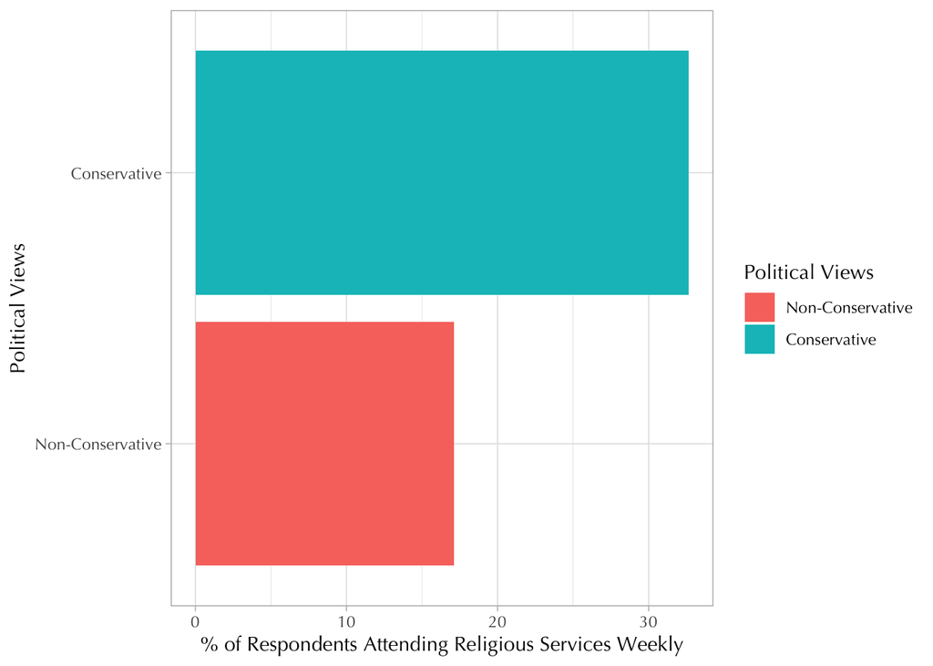

```r
# Visualization
d |>
  group_by(conservative_fct) |>
  summarise(percent = mean(weekly) * 100) |>
  ggplot(aes(x = conservative_fct, y = percent, fill = conservative_fct)) +
  geom_col() +
  coord_flip() + # Flip the coordinates
  labs(y = "% of Respondents Attending Religious Services Weekly",
       x = "Political Views",
       fill = "Political Views")
```

```r
# Bootstrapping method on the sample
boot_dist <- d |>
  specify(weekly ~ conservative_fct) |>
  generate(reps = 1000,
           type = "bootstrap") |>
  calculate(stat = "diff in means",
            order = c("Non-Conservative","Conservative"))

ci <- boot_dist |>
  get_confidence_interval(level = .95)
ci
```

```
# A tibble: 1 × 2
  lower_ci upper_ci
     <dbl>    <dbl>
1   -0.196   -0.115
```

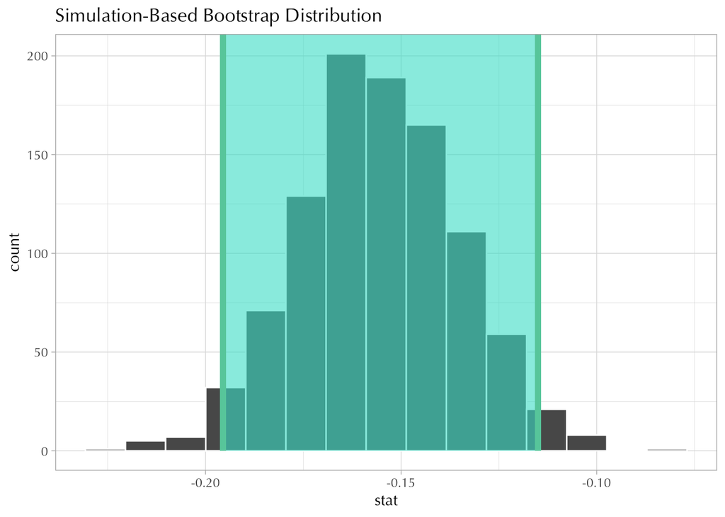

```r
boot_dist |>
  visualize() +
  shade_ci(ci)
```

Hypothesis testing

```r
obs_diff = mean(d$weekly[d$conservative_fct == "Non-Conservative"]) - mean(d$weekly[d$conservative_fct == "Conservative"])

null_dist <- d |>
  specify(weekly ~ conservative_fct) |>
  hypothesize(null = "independence") |>
  generate(reps = 1000,
           type = "permute") |>
  calculate(stat = "diff in means",
            order = c("Non-Conservative","Conservative"))

null_dist |>
  get_p_value(obs_diff, direction = "both")
```

```
# A tibble: 1 × 1
  p_value
    <dbl>
1       0
```

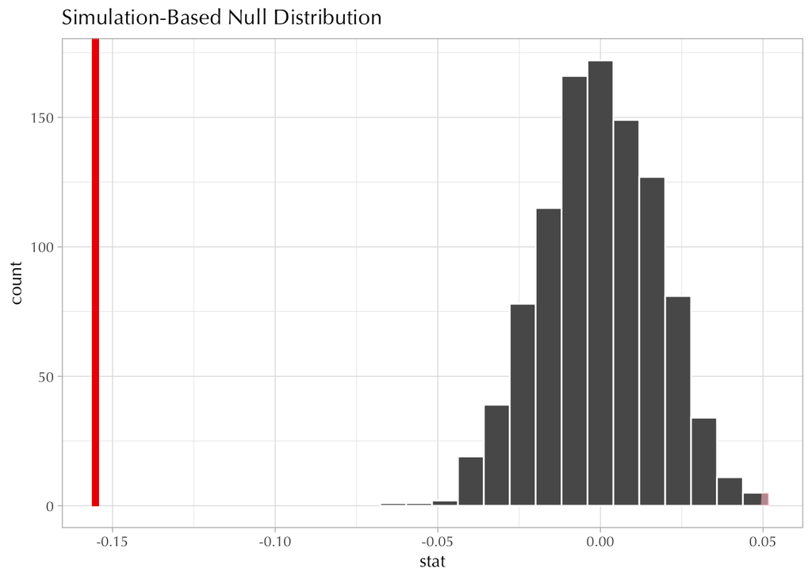

```r
null_dist |>
  visualize() +
  shade_p_value(obs_diff, direction = "both")
```

## 6.2.3 Significance

The proportions of weekly-attending people among those with a non-conservative (liberal or mild) political view is significantly lower than that among those with a conservative political view. Same results can get from either the confidence interval and the hypothesis testing.

## 6.2.4 Heat map

```r
count_df <- d |>
  group_by(polviews, attend) |>
  summarise(value = n()) |>
  mutate(type = "Counts")
rowpct_df <- d |>
  group_by(polviews, attend) |>
  summarise(num_count = n()) |>
  group_by(polviews) |>
  mutate(
    pol_sum = sum(num_count),
    value = num_count/pol_sum,
    type = "Row Percentages",
    forlabel = round(value * 100, 1)) |>
  select(polviews, attend, value, type, forlabel)
colpct_df <- d |>
  group_by(polviews, attend) |>
  summarise(num_count = n()) |>
  group_by(attend) |>
  mutate(
    att_sum = sum(num_count),
    value = num_count/att_sum,
    type = "Column Percentages",
    forlabel = round(value * 100, 1)) |>
  select(polviews, attend, value, type, forlabel)
count_map <- ggplot(count_df, aes(x = factor(attend), y = factor(polviews), fill = value)) +
  geom_tile() +
  geom_text(aes(label = value), color = "white", size = 2) +
  coord_fixed()

rowpct_map <- ggplot(rowpct_df, aes(x = factor(attend), y = factor(polviews), fill = value)) +
  geom_tile() +
  geom_text(aes(label = forlabel), color = "white", size = 2) +
  coord_fixed()

colpct_map <- ggplot(colpct_df, aes(x = factor(attend), y = factor(polviews), fill = value)) +
  geom_tile() +
  geom_text(aes(label = forlabel), color = "white", size = 2) +
  coord_fixed()

library(ggpubr)
combined_figure <- ggarrange(count_map, rowpct_map, colpct_map,
          labels = c("Counts","Row Percentages (%)","Column Percentages (%)"),
          nrow = 1, ncol = 3, legend = "none", align = "h")
```

[output not shown]

[output cut: 28 more lines]

[output not shown]

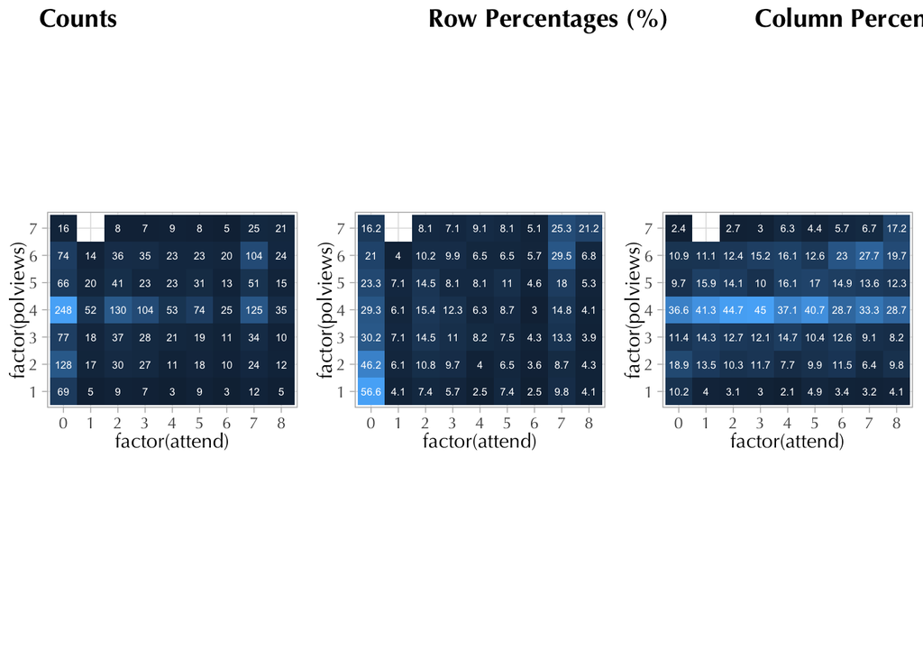

```r
combined_figure #??? How to set to a shared y-axis???
```

From the table of row and column percentages, we can see

## 6.2.5 Bonus: Chi-square test

```r
d |>
  tabyl(conservative_fct, weekly_fct)
```

```
 conservative_fct Less Than Weekly Weekly
 Non-Conservative             1243    257
     Conservative              495    240
```

```r
obs_chi_square <- d |>
  specify(weekly_fct ~ conservative_fct,
          success = "Weekly") |>
  calculate(stat = "Chisq",
            order = c("Non-Conservative", "Conservative"))
obs_chi_square
```

```
Response: weekly_fct (factor)
Explanatory: conservative_fct (factor)
# A tibble: 1 × 1
   stat
  <dbl>
1  67.8
```

```r
## h-test
null_dist <- d |>
  specify(weekly_fct ~ conservative_fct,
          success = "Weekly") |>
  hypothesise(null = "independence") |>
  generate(reps = 1000,
           type = "permute") |>
  calculate(stat = "Chisq",
            order = c("Non-Conservative", "Conservative"))

null_dist |>
  get_p_value(obs_chi_square,
              direction = "greater")
```

```
# A tibble: 1 × 1
  p_value
    <dbl>
1       0
```

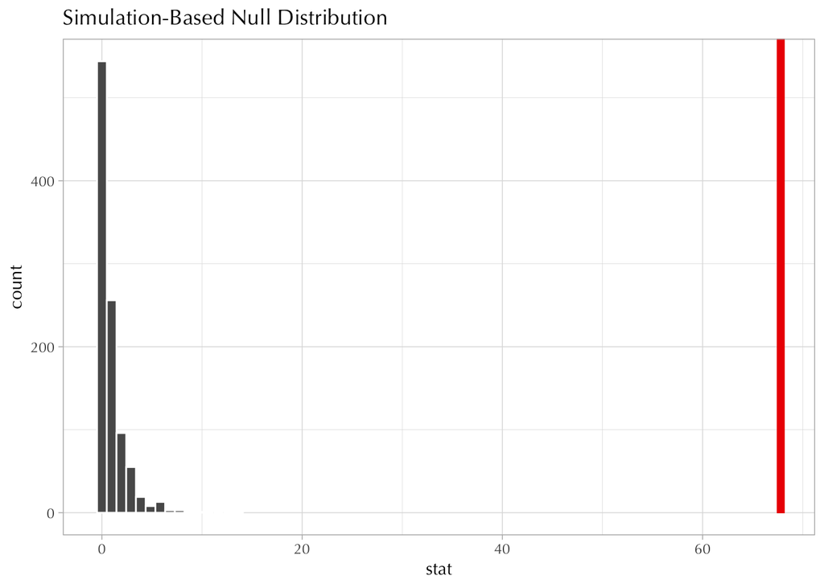

```r
null_dist |>
  visualize() +
  shade_p_value(obs_chi_square,
                direction = "greater")
```

Therefore we can reject the null hypothesis that the two variables are independent of each other.